# PhotoCold

Yunpeng Luo

5/17/2021

## Previous findings

Based on the evaluations presented in [Stocker et al., 2019](https://www.geosci-model-dev-discuss.net/gmd-2019-200/) we identified several sites with an apparent delay in photosynthesis resumption in the early season, while at most other sites, GPP was accurately simulated also in the early season.

Example sites with delay:

- US-Syv
- US-UMB
- US-UMd
- US-WCr
- US-Wi3
- CA-Man
- CA-NS2
- CA-NS4
- CA-NS5
- CA-Qfo
- FI-Hyy
- IT-Tor
- DE-Hai

Example sites without delay:

- IT-Ren
- RU-Ha1
- US-Me2(Csb)
- IT-SRo(Csa)
- BE-Vie
- CH-Cha
- CH-Lae
- CH-Oe1
- DE-Gri
- DE-Obe
- DE-RuR
- DE-Tha
- NL-Hor
- NL-Loo

## General demonstration

**The mean seasonality of sites with delay and sites without delay (accurate predictions of early season GPP) is shown below**

### (1)General overview:

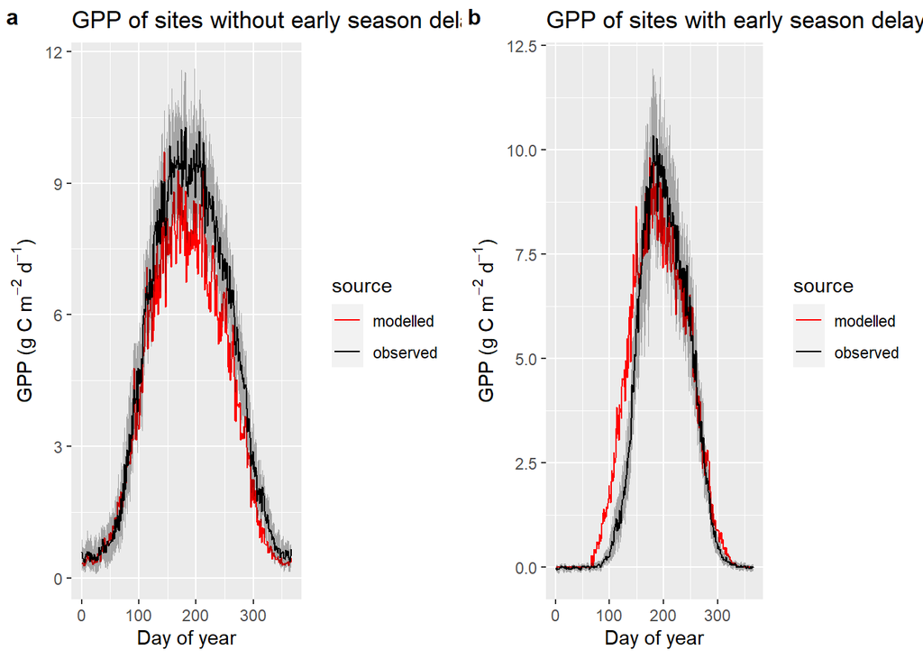

Figure 1 Overview of the sites without and with the delay early season

### (2)Classify the sites with early season model estimation into different climate zones

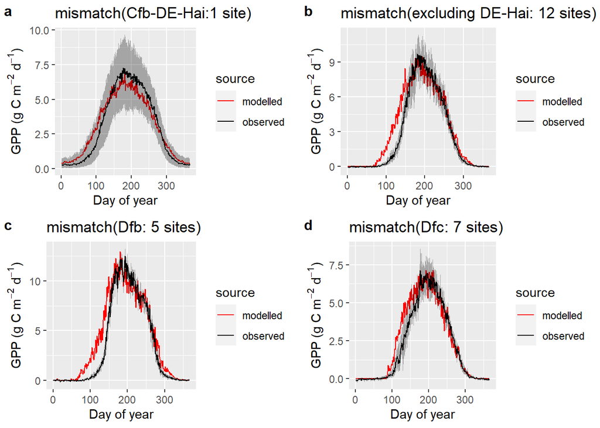

Figure 2. modelling vs observational GPP in different Climate zones.

### (3)Classify the sites with early season model estimation into different PFTs:

**Classify under two major climate zones: Dfb and Dfc**

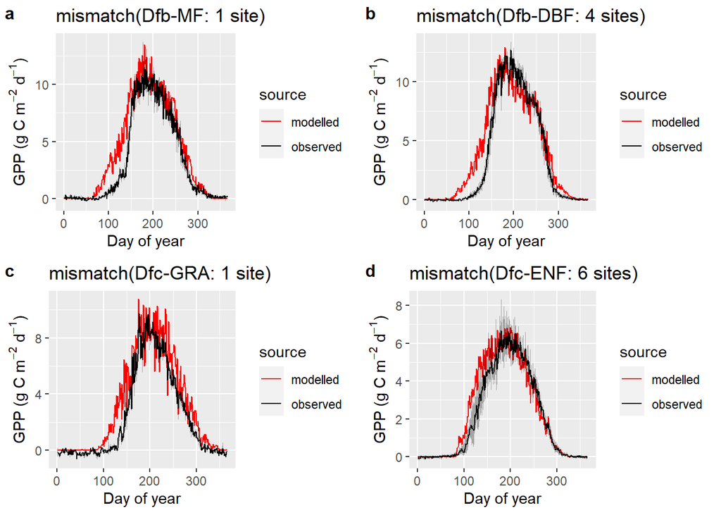

Figure 3. modelling vs observational GPP in different PFTs in Dfb and Dfc climate zone (cold regions).